# STAT 578 - Fall 2019 - Assignment 4

Frederick (Eric) Ellwanger - fre2

November 1, 2019

## Exercise 1

According to one version of Moore’s law, the number of transistors on a state-of-the-art computer microprocessor roughly doubles every two years:
$$T \approx C2^{A/2}$$

#### **(1)(a) Consider the natural logarithm of the number of transistors: log T.**

#### **(1)(a)(i) Demonstrate that, according to Moore’s law, log T should roughly follow a simple linear regression on A. Also, what should be the value of the coeffcient of A?**

$log(T) \approx log(C2^{A/2})$  
$log(T) \approx log(C) + log(2^{A/2})$  
$log(T) \approx log(C) + A/2*log(2)$

**This demonstrates that log(T) roughly follows a simple linear regression of the form:**  
**$log(T) \approx \beta_1 + \beta_2 A$ where $\beta_1 = log(C)$ and $\beta_2 = \frac{log(2)}{2}$**  
**The coefficient of A is $\frac{log(2)}{2} \approx$ 0.347**

#### **(1)(a)(ii) Plot the data points as log transistor count versus year.**

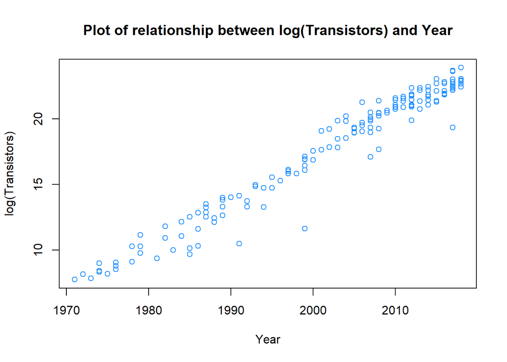

```r
ml = read.csv("mooreslawdata.csv", header=TRUE)
plot(log(Transistors) ~ Year, data = ml,
     main = "Plot of relationship between log(Transistors) and Year", col = "dodgerblue")
```

#### **(1)(b) Consider a normal-theory simple linear regression model of log transistor count on centered year of the form:**

$$log(T_i)|\beta,\sigma^2,A_i \hspace{2 mm} \sim \hspace{2 mm} indep. N(\beta_1+\beta_2(A_i-\bar{A}),\sigma^2) \hspace{8 mm} i = 1,...,161$$

where $\bar{A}$ is the avergae of $A_i$ over all observations. Of course, Moore’s law specifies a particular value for $\beta_2$, but your initial model will not assume this. Use independent priors
$$\beta_1,\beta_2 \hspace{2 mm} \sim \hspace{2 mm} iid N(0, 1000^2)$$
$$\sigma^2 \hspace{2 mm} \sim \hspace{2 mm} Inv-gamma(0.001, 0.001)$$

#### **(1)(b)(i) List an appropriate JAGS model**

```r
ml$logT = log(ml$Transistors)
ml$Ycent = ml$Year - mean(ml$Year)
```

```
model {
   for(i in 1:length(logT)) {
      logT[i] ~ dnorm(beta1 + beta2*Ycent[i], sigmasqinv)
   }

   beta1 ~ dnorm(0, (1/1000^2))
   beta2 ~ dnorm(0, (1/1000^2))
   sigmasqinv ~ dgamma(0.001, 0.001)

   sigmasq = 1/sigmasqinv
   }
}
```

```r
library(rjags)

#Set overdispersed starting points
inits = list(list(beta1 = 1700, beta2 = 1700, sigmasqinv = 100),
             list(beta1 = 1700, beta2 = -1700, sigmasqinv = 0.001),
             list(beta1 = -1700, beta2 = 1700, sigmasqinv = 0.001),
             list(beta1 = -1700, beta2 = -1700, sigmasqinv = 100))

#Setup model
chains = 4
m1 = jags.model("transistor.bug", ml, inits, n.chains = chains)
```

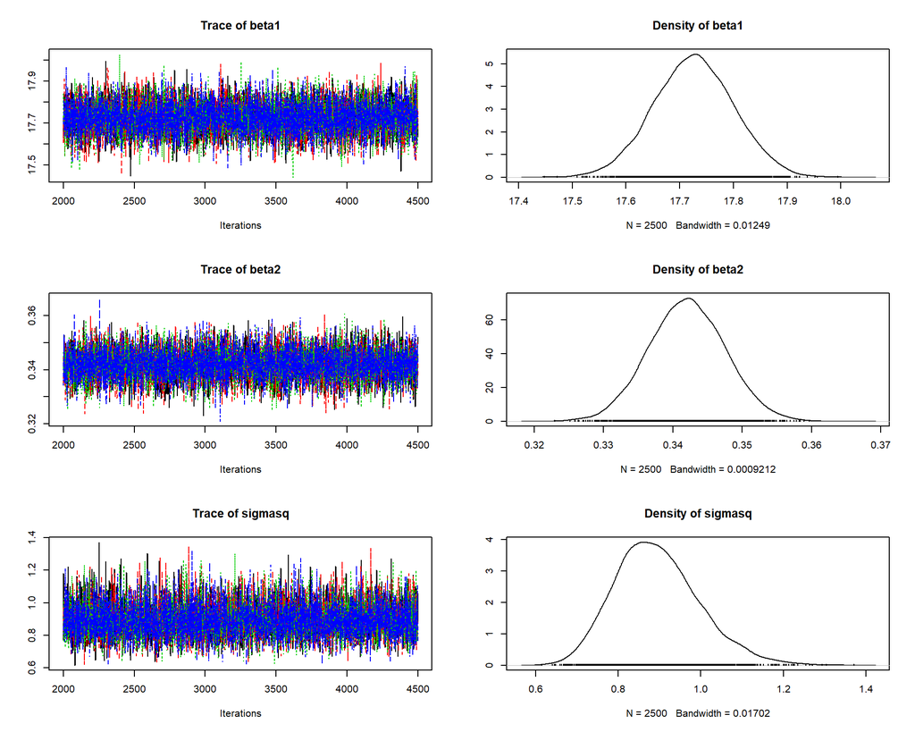

```r
#Run burn-in
update(m1, 2000)

#Run model
iters = 2500
x1 = coda.samples(m1, c("beta1", "beta2", "sigmasq"), n.iter = iters)

#Check for convergence
plot(x1, smooth = FALSE)
```

**None of the parameter graphs show any concerns with convergence**

```r
#Another check for problems with convergance
gelman.diag(x1, autoburnin = FALSE)
```

```
## Potential scale reduction factors:
##
##         Point est. Upper C.I.
## beta1            1          1
## beta2            1          1
## sigmasq          1          1
##
## Multivariate psrf
##
## 1
```

**Gelman-Rubin statistics do not show any issues with convergance**

```r
#Another check for convergance
effectiveSize(x1)
```

```
##   beta1   beta2 sigmasq
##   10000   10549    9740
```

**The sample sizes are adequate**

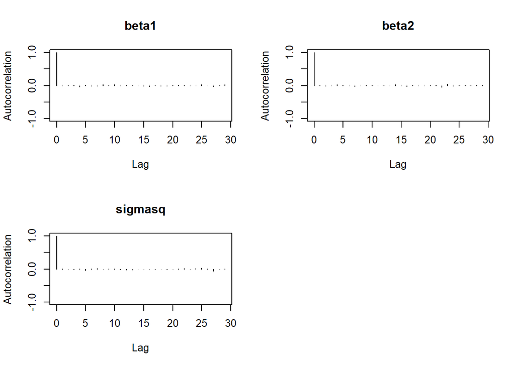

```r
#Another check for convergance (just first chain )
autocorr.plot(x1[[1]])
```

**Autocorrelation plots do not show any issues with mixing**

**There does not appear to be any issues with convergance**

#### **(1)(b)(ii) List the `coda` summary of your results for $\beta_1$, $\beta_2$, and $\sigma^2$**

```r
summary(x1)
```

```
##
## Iterations = 2001:4500
## Thinning interval = 1
## Number of chains = 4
## Sample size per chain = 2500
##
## 1. Empirical mean and standard deviation for each variable,
##    plus standard error of the mean:
##
##           Mean      SD  Naive SE Time-series SE
## beta1   17.726 0.07433 0.0007433      0.0007434
## beta2    0.342 0.00548 0.0000548      0.0000535
## sigmasq  0.894 0.10259 0.0010259      0.0010399
##
## 2. Quantiles for each variable:
##
##           2.5%    25%    50%    75%  97.5%
## beta1   17.581 17.675 17.726 17.776 17.871
## beta2    0.331  0.338  0.342  0.346  0.353
## sigmasq  0.716  0.821  0.886  0.957  1.116
```

#### **(1)(b)(iii)Give the approximate posterior mean and 95% posterior credible interval for the slope. Does the interval contain the value you determined in part (a), in accordance with Moore’s law?**

```r
summary(x1)$statistics['beta2','Mean']
```

```
## [1] 0.342
```

**The approximate posterior mean for the slope is 0.342**

```r
summary(x1)$quantiles['beta2',c('2.5%', '97.5%')]
```

```
##  2.5% 97.5%
## 0.331 0.353
```

**The approximate 95% posterior credible interval for the slope is (0.331, 0.353)**

**This interval does contain the value calculted in part a : 0.347**

#### **(1)(b)(iv)Give the approximate posterior mean and 95% posterior credible interval for the intercept.**

```r
summary(x1)$statistics['beta1','Mean']
```

```
## [1] 17.7
```

**The approximate posterior mean for the intercept is 17.726**

```r
summary(x1)$quantiles['beta1',c('2.5%', '97.5%')]
```

```
##  2.5% 97.5%
##  17.6  17.9
```

**The approximate 95% posterior credible interval for the intercept is (17.581, 17.871)**

#### **(1)(c) Consider the model of the previous part. You will use it to predict the transistor count on a microprocessor introduced in 2020, and also (just for fun) to see if it extrapolates back to the invention of the transistor.**

#### **(1)(c)(i) List a modifed JAGS model appropriate for answering the subparts below.**

```
model {
   for(i in 1:length(Transistors)) {
      log(Transistors[i]) ~ dnorm(beta1 + beta2*Ycent[i], sigmasqinv)
   }
   Tnew ~ dnorm(beta1 + beta2*YNewcent, sigmasqinv)

   beta1 ~ dnorm(0, (1/1000^2))
   beta2 ~ dnorm(0, (1/1000^2))
   sigmasqinv ~ dgamma(0.001, 0.001)

   sigmasq = 1/sigmasqinv

   A0 = mean(Year) - beta1/beta2
}
```

**Now run your model. Make sure to use multiple chains with overdispersed starting points, check convergence, and monitor parameters for at least 2000 iterations (per chain) after burn-in.**

```r
#Set overdispersed starting points
inits = list(list(beta1 = 1700, beta2 = 1700, sigmasqinv = 100),
             list(beta1 = 1700, beta2 = -1700, sigmasqinv = 0.001),
             list(beta1 = -1700, beta2 = 1700, sigmasqinv = 0.001),
             list(beta1 = -1700, beta2 = -1700, sigmasqinv = 100))

#Setup model
Newcent = 2020 - mean(ml$Year)
m2 = jags.model("transistormod.bug", as.list(c(ml, YNewcent = Newcent)),
                 inits, n.chains = 4)
```

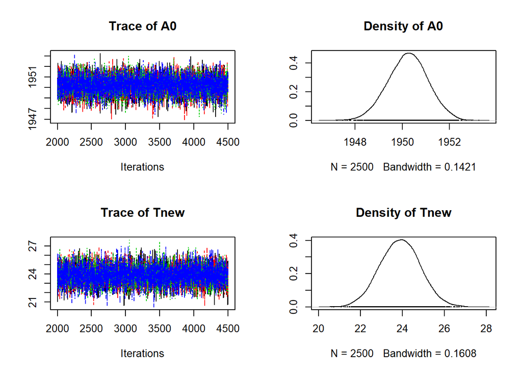

```r
#Run burn-in
update(m2, 2000)

#Run model
x2 = coda.samples(m2, c("Tnew", "A0"), n.iter = 2500)

#check for convergance
plot(x2, smooth = FALSE)
```

**None of the parameter graphs show any concerns with convergence**

```r
#Another check for problems with convergance
gelman.diag(x2, autoburnin = FALSE)
```

```
## Potential scale reduction factors:
##
##      Point est. Upper C.I.
## A0            1          1
## Tnew          1          1
##
## Multivariate psrf
##
## 1
```

**Gelman-Rubin statistics do not show any issues with convergance**

```r
#Another check for convergance
effectiveSize(x2)
```

```
##    A0  Tnew
## 10212 10256
```

**The sample sizes are adequate**

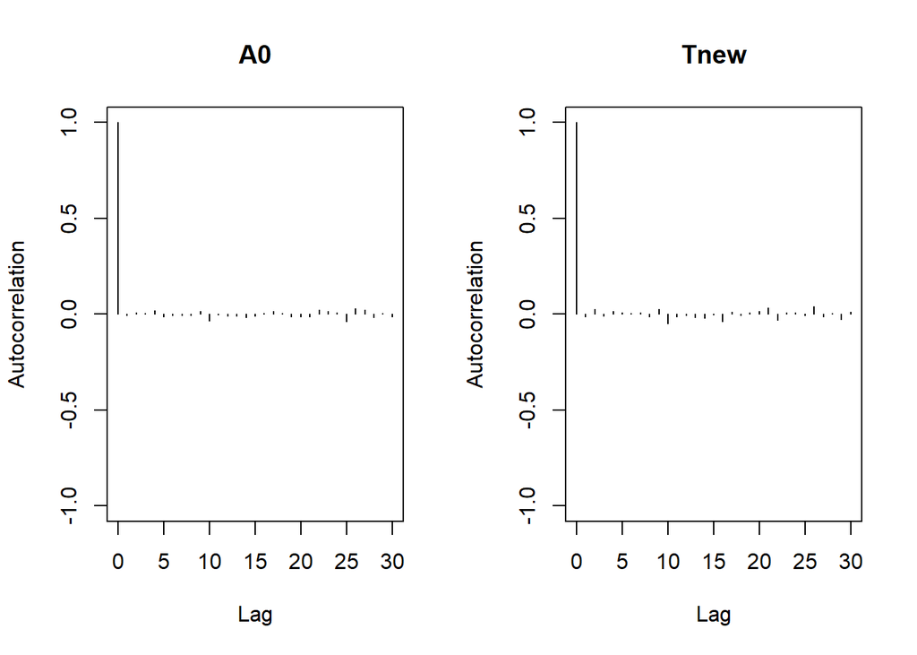

```r
#Another check for convergance (just first chain )
autocorr.plot(x2[[1]])
```

**Autocorrelation plots do not show any issues with mixing**

**There does not appear to be any issues with convergance**

#### **(1)(c)(ii) List the `coda` summary you will use to help answer the subparts below.**

```r
summary(x2)
```

```
##
## Iterations = 2001:4500
## Thinning interval = 1
## Number of chains = 4
## Sample size per chain = 2500
##
## 1. Empirical mean and standard deviation for each variable,
##    plus standard error of the mean:
##
##        Mean    SD Naive SE Time-series SE
## A0   1950.2 0.846  0.00846        0.00838
## Tnew   23.9 0.957  0.00957        0.00946
##
## 2. Quantiles for each variable:
##
##      2.5%    25%    50%    75%  97.5%
## A0   1949 1949.7 1950.3 1950.8 1951.9
## Tnew   22   23.2   23.9   24.5   25.8
```

#### **(1)(c)(iii) Give an approximate 95% posterior predictive interval for the transistor count, in billions, on a microprocessor introduced in the year 2020. (Note: This is for the count, NOT the log count.)**

```r
exp(summary(x2)$quantiles['Tnew',c('2.5%', '97.5%')])/1000000000
```

```
##   2.5%  97.5%
##   3.65 154.56
```

**The approximate 95% posterior predictive interval for the transistor count in billions, on a m icropocessor introduced in the year 2020 is (3.65, 154.56)**

#### **(1)(c)(iv) Explain why the model suggests that the transistor was invented in the year:**

$$\bar{A} - \frac{\beta_1}{\beta_2}$$

**To find the year the model predicts the transistor was invented, we need to find where the transistor count is 0**

$$y = 0 = \beta_1 + \beta_2*(A - \bar{A})$$
$$-\frac{\beta_1}{\beta_2} = A - \bar{A}$$
$$A = \bar{A} - \frac{\beta_1}{\beta_2}$$

**This explains how the model suggests the transistor was invented in the year $\bar{A} - \frac{\beta_1}{\beta_2}$**

**give an approximate 95% posterior interval for this quantity. (You may compare this to the actual year in which the transistor was invented.)**

```r
summary(x2)$quantiles['A0',c('2.5%', '97.5%')]
```

```
##  2.5% 97.5%
##  1949  1952
```

**The approximate 95% posterior interval for this quantity is (1949, 1952)**

**This compares very close to the actual year of 1947 (really December 23, 1947, so you could almost call that 1948)**

#### **(1)(d) One way to check for evidence of outliers is a posterior predictive p-value based on test quantity**

$$T(y, X, \theta) = \underset{i}{max} |\frac{\epsilon_i}{\sigma}|$$

**where $\epsilon_i$ is the error for observation i. The larger this quantity is, the more we should suspect the existence of an outlier.**

#### **(1)(d)(i) Show R code for computing the simulated error vectors $\epsilon$ (as rows of a matrix).**

```r
#Get matrixes/vectors from simulated MCMC model
betas.sim = as.matrix(x1)[, 1:2]
sigma.2.sim = as.matrix(x1)[, 3]

#Create X matrix with first column as 1's
X = as.matrix(cbind(rep(1, nrow(ml)), ml$Ycent))

nsims = chains*iters

#Create empty matrix to store error vectors
error.sim = matrix(NA, nsims, nrow(ml))

#Calculate simulated error vectors
for (s in 1:nsims){
       error.sim[s, ] = log(ml$Transistors) - X %*% cbind(betas.sim[s, ])
}
```

#### **(1)(d)(ii) Show R code for computing simulated replicate error vectors $\epsilon^{rep}$ (as rows of a matrix), which are the error vectors for the replicate response vectors $y^{rep}$.**

```r
#Replicated errors
error.rep = matrix(rnorm(nsims*nrow(ml), mean = 0, sd = sqrt(sigma.2.sim)), nsims, nrow(ml))
```

#### **(1)(d)(iii) Show R code for computing the simulated values of $T(y, X, \theta)$ and the simulated values of $T(y^{rep}, X, \theta)$**

```r
#Simulated values of T(y, X, theta)
Tysim = apply(abs(error.sim/sqrt(sigma.2.sim)), 1, max)

#Simulated values of (Yrep, X, theta)
Tyrep = apply(abs(error.rep)/sqrt(sigma.2.sim), 1, max)
```

#### **(1)(d)(iv) Plot the simulated values of $T(y^{rep},X, \theta)$ versus those of $T(y, X, \theta)$, with a reference line indicating where $T(y^{rep}, X, \theta) = T(y, X, \theta)$.**

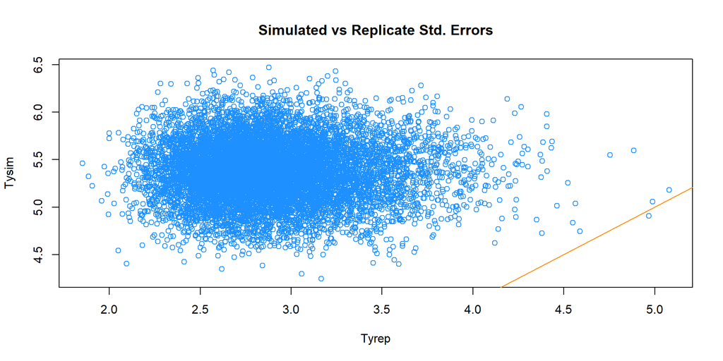

```r
plot(Tyrep, Tysim, col = "dodgerblue", main = "Simulated vs Replicate Std. Errors")
abline(0, 1, col = "darkorange")
```

#### **(1)(d)(v) Compute the approximate posterior predictive p-value, and make an appropriate conclusion based on it. (Is there evidence for an outlier?)**

```r
mean(Tyrep >=Tysim)
```

```
## [1] 0.0001
```

**The approximate posterior predictive p-value is 0**

**The test quantity and plot seem to indicate that there may be an issue with outliers**

#### **(1)(d)(vi) Name the microprocessor that appears to be the most extreme outlier.**

```r
#find largest error in each yi
p = apply(abs(error.sim/sqrt(sigma.2.sim)), 1, which.max)

#Find most common max error
y = table(p)
(proc = as.character(ml$Processor[as.numeric(names(y)[which(y==max(y))])]))
```

```
## [1] "ARM 9TDMI"
```

**The micrproccesor that appears to be the most extreme outlier is the ARM 9TDMI**